# HW4

Corinna Hong

February 24, 2020

## 1. Visualizing patterns of change for climate change data

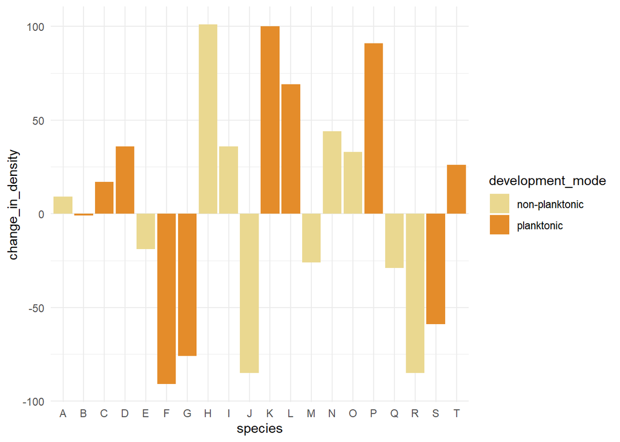

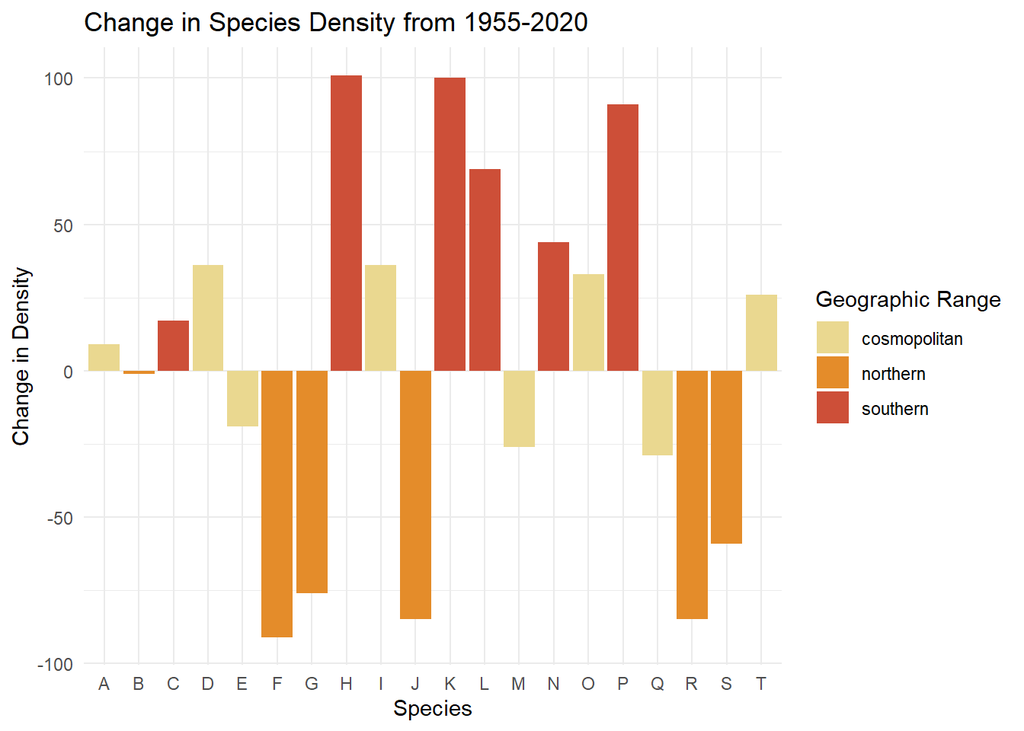

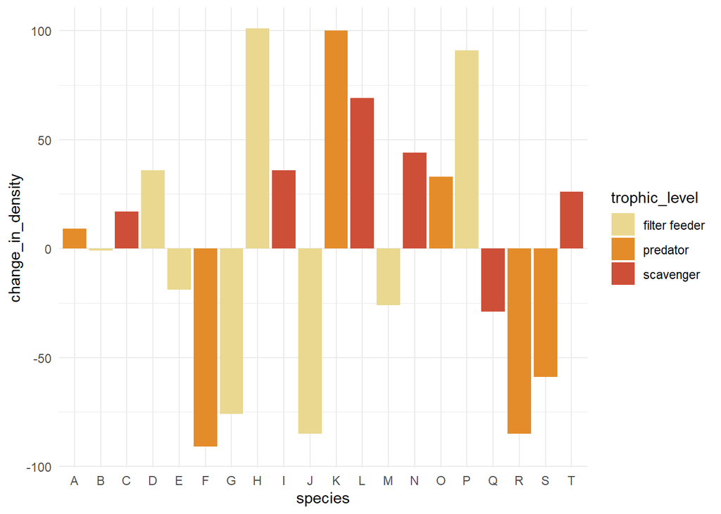

When grouping these species by geographic category, a pattern of change emerges. Data shows that a species with ranges south of the Northern California coastal site have increased over the past 65 years. On the other hand, species with ranges north of the study site have decreased. This pattern suggests that climatic changes have impacted marine communities in California. As climate change leads to global increases in sea surface temperature, species who are adapted to cooler water temperatures (those who have northern ranges) are experiencing decreases in density. The opposite happens to species who have southern ranges and are already adapted to warmer water temperatures.

## 2. Visualizing changes at nuclear power plant

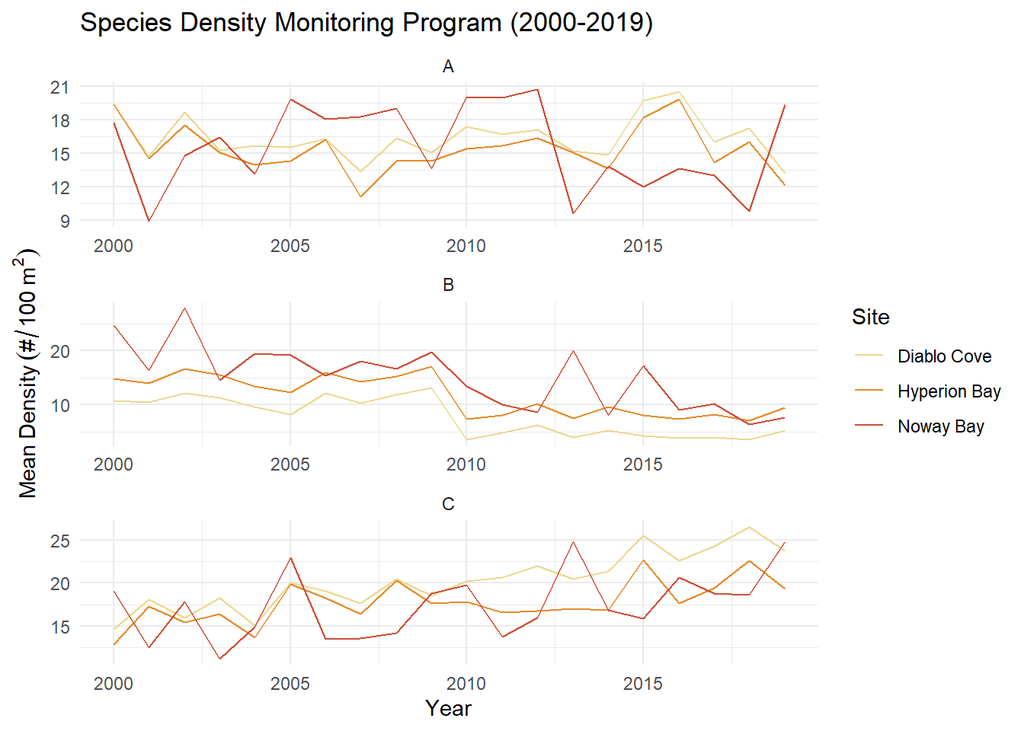

Data from the El Diablo power plant monitoring program shows slight impacts to species C after the plant became operational in 2010. Shortly after the plant became operational, species C densities increased in Diablo Bay compared to in Hyperion Bay. I used Hyperion Bay as a control in this analysis because, for all three species this site was most similar to Diablo Bay before 2010. In 2014, species C densities increased again in Hyperion Bay, and now the two Bays show similar patterns of density changes.

## 3. Visualizing patterns of change for crab fishery

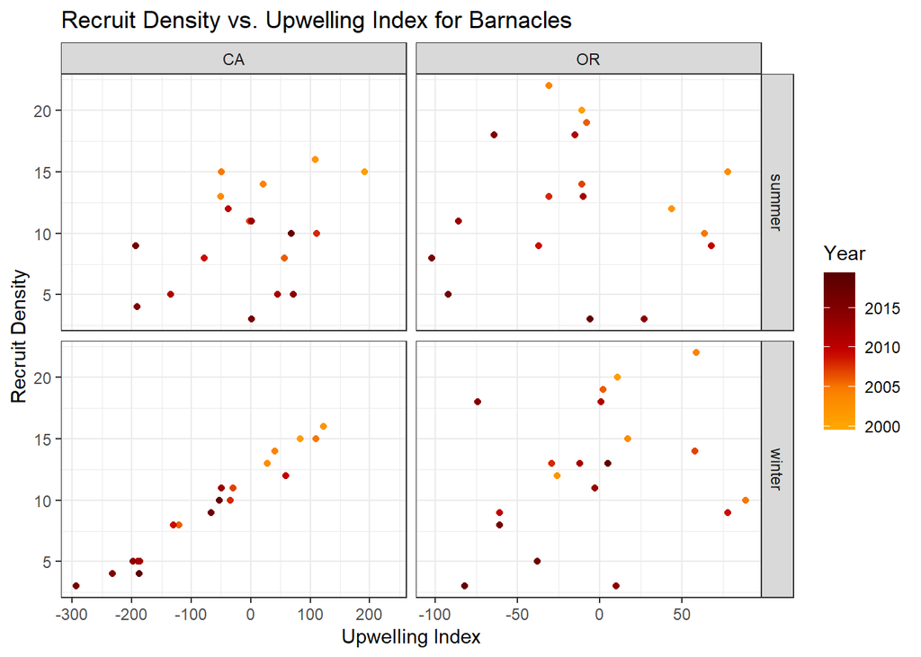

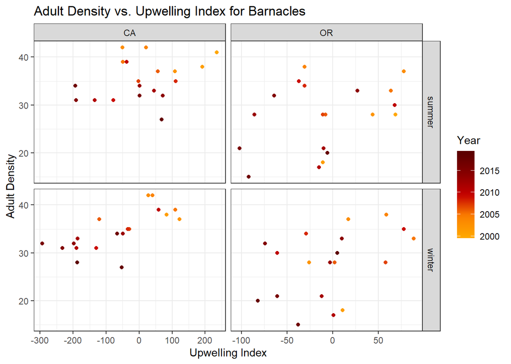

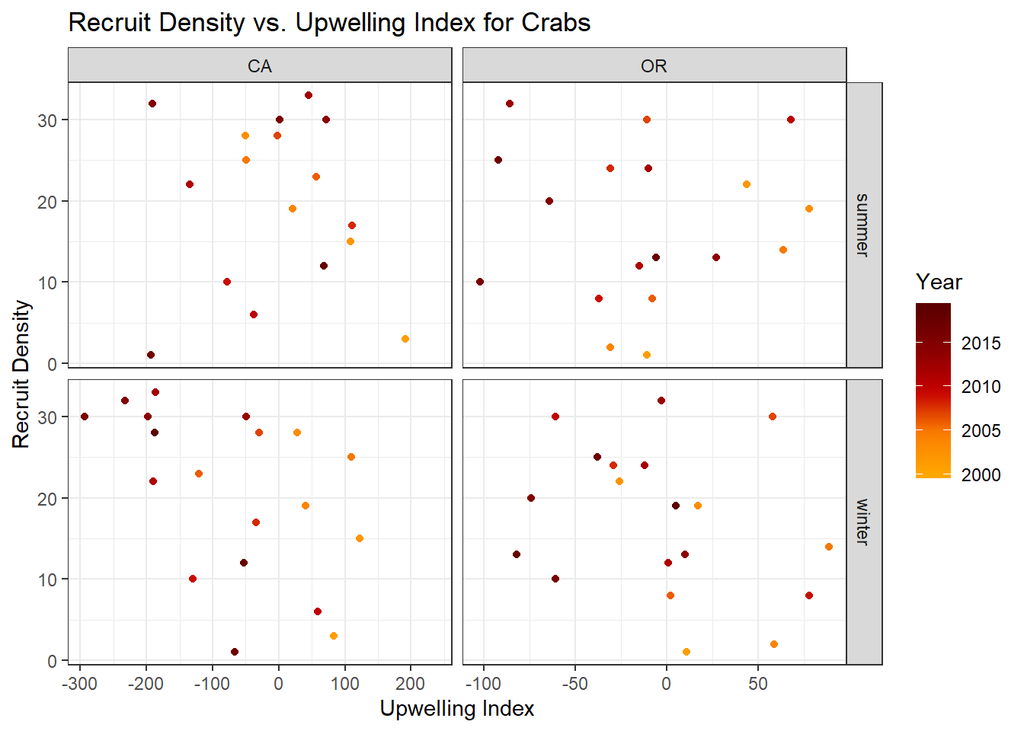

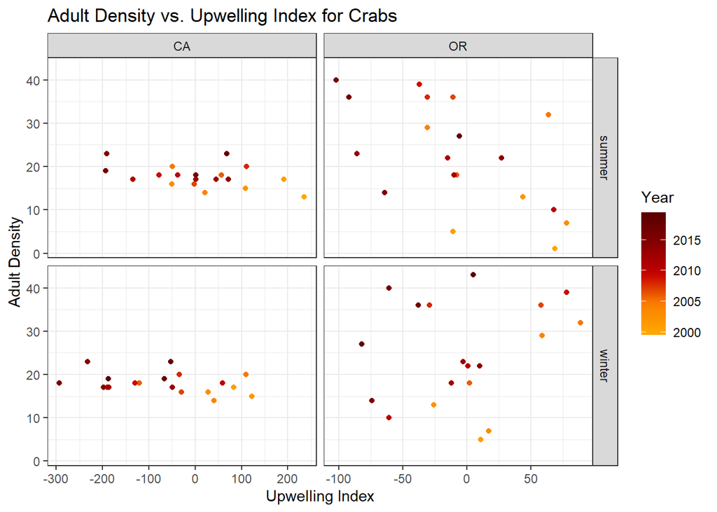

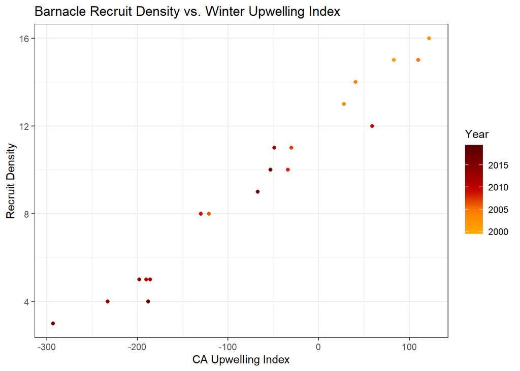

Winter upwelling indices affect recruit densities, because female adults are producing new eggs in this season. In spring they spawn, resulting in that year’s recruit density. In the summer, the juveniles are developing and feeding. Summer upwelling indices will affect food availability and therefore the resulting adult density for that year. The data show a strong positive relationship between recruit density and the winter upwelling index for barnacles in California. Downwelling (negative values) decreases recruit density and upwelling (positive values) increases recruit density. This makes sense because downwelling is associated with low nutrients and rare phytoplankton. This, of course, would negatively affect the adult population and therefore cause them to produce fewer eggs.

### Figures for HW 5 Management Plan

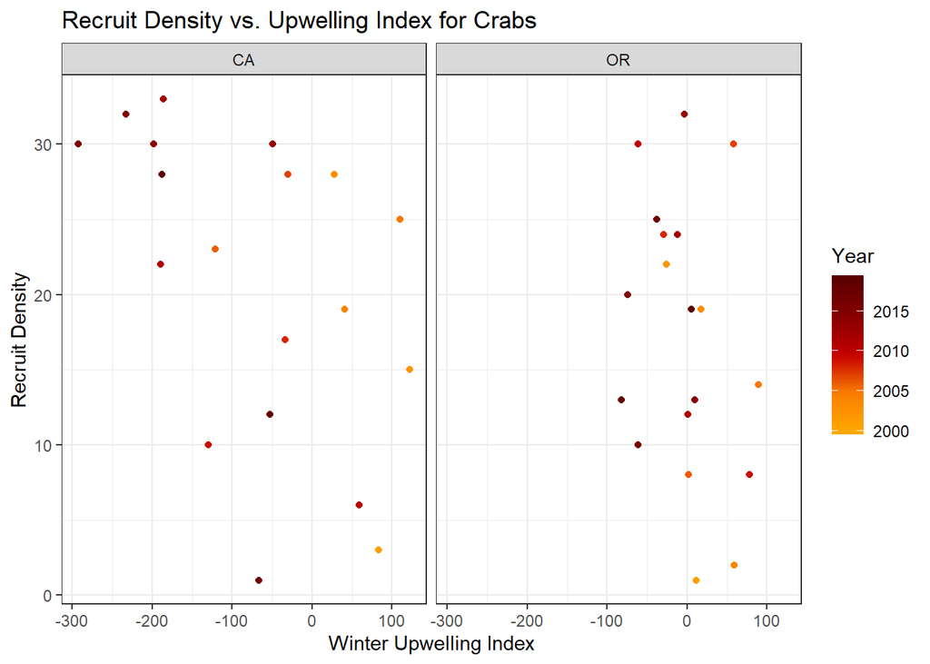

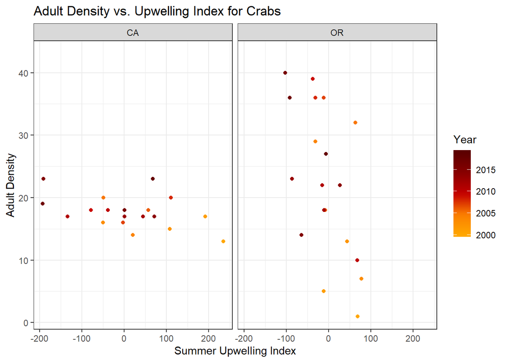